# Lab 2

Jack Novak

2/19/2021

**Searching for the Best Chocolates**

We will be exploring what aspects of the chocolates may affect taste. Before setting off to the exploration, answer the following questions.

```r
choco <- read.csv("https://raw.githubusercontent.com/xdaiISU/ds202materials/master/hwlabs/data/choco.csv")
str(choco)
```

```
## 'data.frame':    2312 obs. of  13 variables:
##  $ REF                 : int  2454 2458 2454 797 797 1015 1019 1011 1019 1011 ...
##  $ Company             : Factor w/ 541 levels "5150","A. Morin",..: 1 1 1 2 2 2 2 2 2 2 ...
##  $ Location            : Factor w/ 67 levels "Amsterdam","Argentina",..: 63 63 63 19 19 19 19 19 19 19 ...
##  $ Date                : int  2019 2019 2019 2012 2012 2013 2013 2013 2013 2013 ...
##  $ Bean_Origin         : Factor w/ 63 levels "Australia","Belize",..: 30 14 54 38 5 62 38 16 38 7 ...
##  $ Specific_Bean_Origin: Factor w/ 1436 levels "\"heirloom\", Arriba Nacional",..: 141 1435 666 1029 179 289 267 482 267 189 ...
##  $ Cocoa_Percent       : num  76 76 76 63 70 70 63 70 70 70 ...
##  $ Ingredients         : Factor w/ 21 levels "1- B","2- B,C",..: 7 7 7 14 14 14 7 14 14 14 ...
##  $ Characteristics1    : Factor w/ 450 levels "accesible","accessible",..: 81 81 311 131 430 272 403 328 81 240 ...
##  $ Characteristics2    : Factor w/ 502 levels "","\"Andes\" mint",..: 29 482 137 236 304 301 94 304 408 NA ...
##  $ Characteristics3    : Factor w/ 341 levels "","accessible",..: 115 260 29 251 NA 48 306 66 148 NA ...
##  $ Characteristics4    : Factor w/ 88 levels "acidic","apple",..: NA NA NA NA NA 66 NA 29 NA NA ...
##  $ Rating              : num  3.75 3.5 3.25 3.75 3.5 4 4 3.75 3.5 3.25 ...
```

How are the ratings distributed? Create both a histogram and a boxplot and describe them. Don’t forget to mention outliers, if there are any.

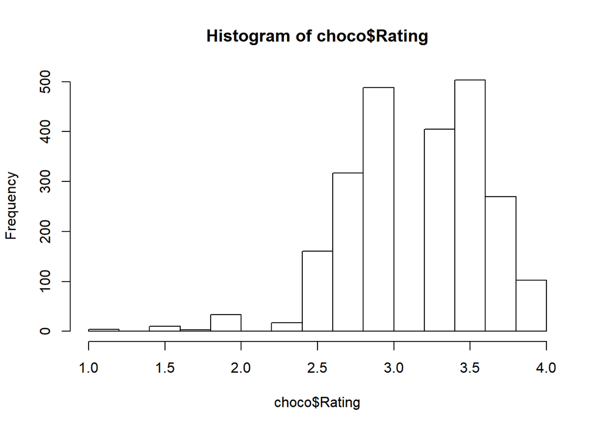

```r
hist(choco$Rating)
```

Chocolate ratings range between 1 and 4 with a left skewed distribution.

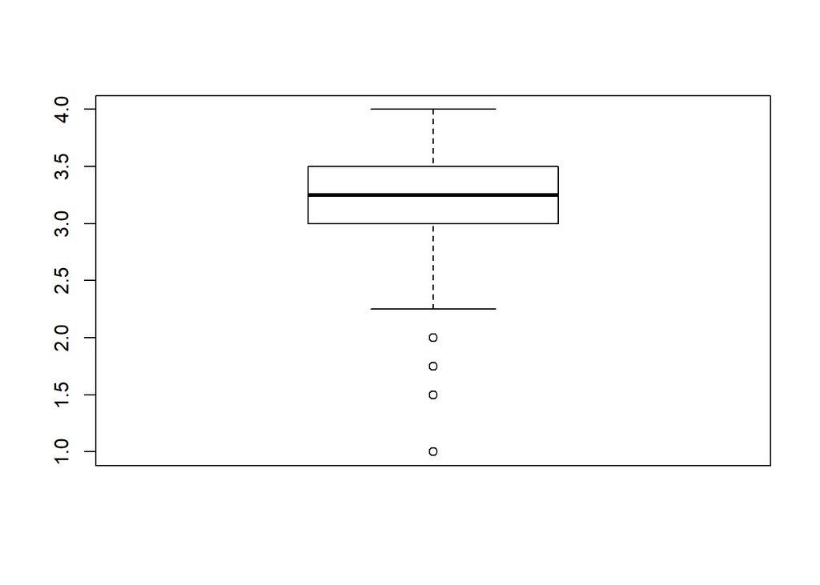

```r
boxplot(choco$Rating)
```

How does the number of ratings depend on the location of the company? Draw a bar chart of the number of reports. Do ratings depend on the cacao percentage of a chocolate bar? Create both numerical and graphical summaries, and explain. [Hint: Think about why the scatterplot is not a very good choice for visualization here.] Now, we are ready to explore.

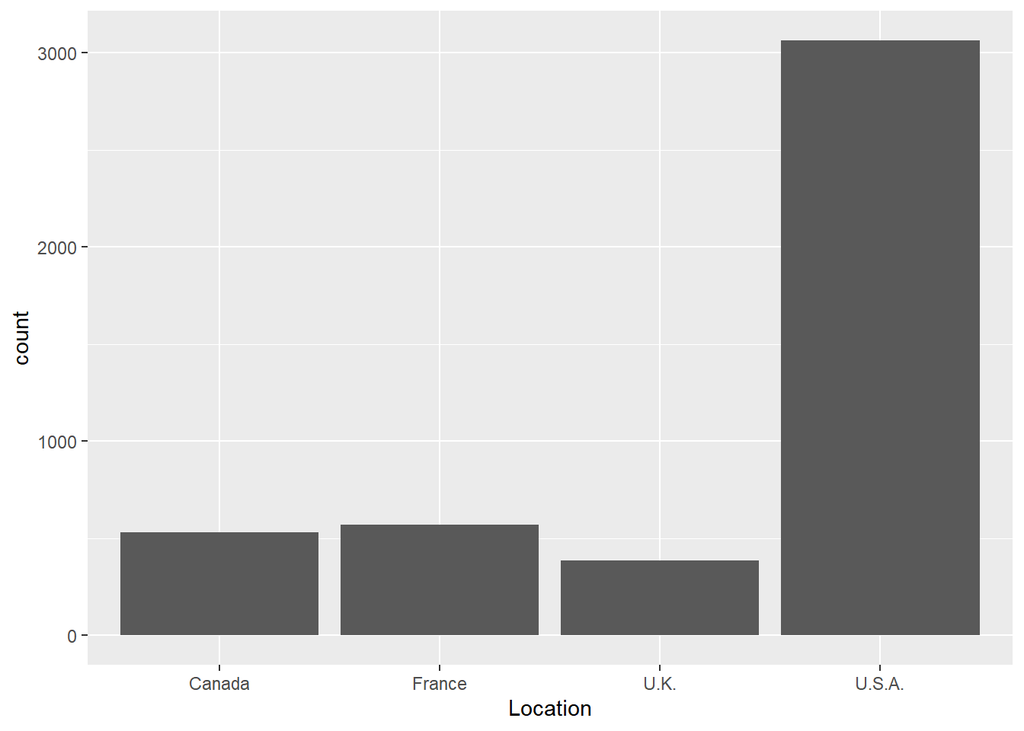

```r
library(ggplot2)
toplocations <- choco[choco$Location %in% c("U.S.A.","France", "Canada","U.K." ),]
ggplot(toplocations, aes(x=Location, weight=Rating)) + geom_bar()
```

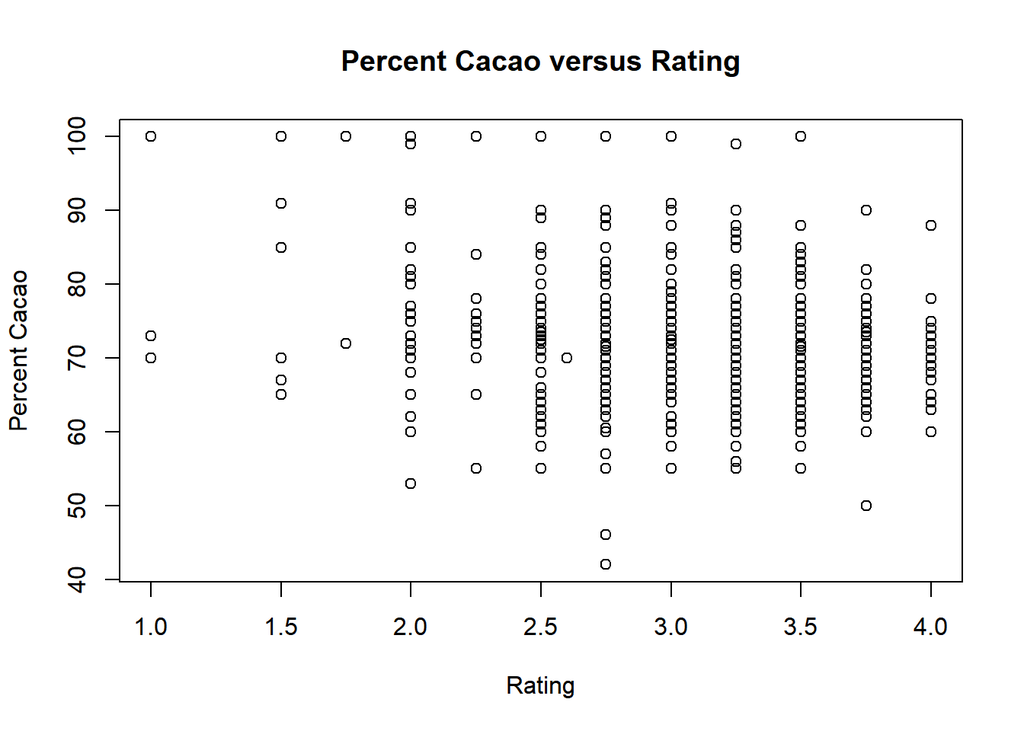

```r
plot(choco$Rating, choco$Cocoa_Percent, xlab='Rating', ylab='Percent Cacao', main='Percent Cacao versus Rating')
```

```r
cor(choco$Rating, choco$Cocoa_Percent)
```

```
## [1] -0.1510178
```

There is a slight negative correlation between percent cacao and the rating.

```r
mean(choco$Cocoa_Percent)-median(choco$Cocoa_Percent)
```

```
## [1] 1.647708
```

How do different bean origins compare in terms of the flavor of chocolates? Are beans from some places better than the other? Create both numerical and graphical summaries, and explain. Brainstorm two analyses you would like to perform (with your teammates). Describe in plain language what comparisons are you making. Create suitable numerical and graphical summaries for your analyses. Describe the results.

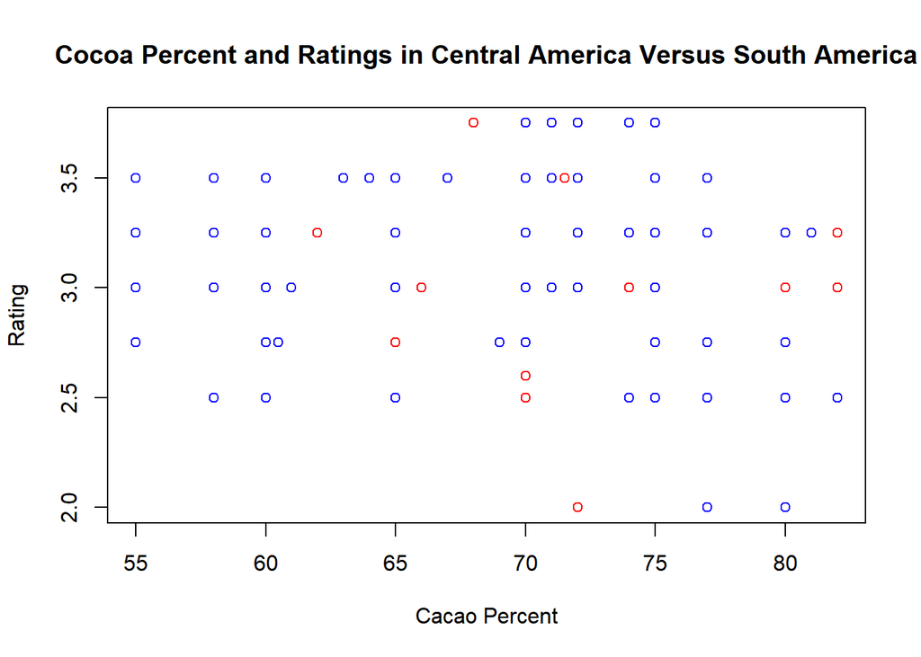

```r
centralamerica <- choco[c(choco$Location %in% c("Costa Rica","El Salvador", "Mexico", "Dominican Republic", "Nicaragua")),]
southamerica <- choco[c(choco$Location %in% c("Colombia", "Brazil", "Ecuador", "Argentina", "Brazil", "Venezuela")),]

plot(centralamerica$Cocoa_Percent, centralamerica$Rating, col='red', xlab='Cacao Percent', ylab='Rating', main='Cocoa Percent and Ratings in Central America Versus South America')
points(southamerica$Cocoa_Percent, southamerica$Rating, col='blue')
```

```r
mean(southamerica$Rating)
```

```
## [1] 3.130137
```

```r
mean(centralamerica$Rating)
```

```
## [1] 3.081707
```

On average, chocolate from South American countries has a higher rating (3.13) than chocolate from Central American countries (3.08).

```r
t.test(centralamerica$Rating, southamerica$Rating, var.equal=TRUE)
```

```
##
##  Two Sample t-test
##
## data:  centralamerica$Rating and southamerica$Rating
## t = -0.60778, df = 185, p-value = 0.5441
## alternative hypothesis: true difference in means is not equal to 0
## 95 percent confidence interval:
##  -0.2056345  0.1087751
## sample estimates:
## mean of x mean of y
##  3.081707  3.130137
```

There is insufficient evidence to reject the null hypothesis that the mean rating in South America is equal to the mean rating in Central America.

Collaboration Workflow Overview Discuss with your teammate plans for the analyses. Include your own analysis in an individual file. This file is the “scratch file”, which should include all your own exploration and analysis, even if you would not show those results in your final report. Name your own file as either individual1.Rmd, individual2.Rmd, or individual3.Rmd after coordinating with your teammate(s), if you have. After you have decided the exploration/analysis to show in your report, collaborate on a single team.Rmd file which includes the final analysis. Only the team.Rmd and the knitted team.html files will be graded, even if you are working on this lab by yourself. Recap: Collaborating on a GitHub repository Individual 1:

Log into github, and create a repository called ds202_lab2 Go into the settings of the repository and add your team member as a collaborator Push individual1.Rmd and individual1.html to the remote. When the above is finished, Individual 2:

Log into GitHub and accept the invitation to work on the team repo. Clone the remote repo of Individual 1’s. Add individual2.Rmd and individual2.html to the local repo, and push. (Repeat if there is a third teammate)

Working on the team.Rmd One of the teammates will make a draft team.Rmd, include the file in a git commit, and then push to the remote. The other teammate will pull, make additions and modifications to team.Rmd, create a commit, and then push. Repeat as necessary.